# Stat2017 (Part 3)

2017-Aug-04

## Analysis of variance

- Regression models predict a quantitative response variable from quantitative predictor variables.
- When factors are included as explanatory variables, our focus usually shifts from prediction to understanding group differences, and the methodology is referred to as analysis of variance (ANOVA) .

## aov()

**aov(*formula*, data=*dataframe*)**

| Design | Formula |
| --- | --- |
| One-way ANOVA | y ~ A |
| One-way ANCOVA with 1 covariate | y ~ x + A |
| Two-way factorial ANOVA | y ~ A * B |
| Two-way factorial ANCOVA with 2 covariates | y ~ x1 + x2 + A * B |
| Randomized block | y ~ B + A (where B is a blocking factor) |
| One-way within-groups ANOVA | y ~ A + Error(Subject/A) |
| Repeated measures ANOVA with 1 within-groups factor (W) and 1 between-groups factor (B) | y ~ B * W + Error(Subject/W) |

## One-way ANOVA

In a one-way ANOVA , you’re interested in comparing the dependent variable means of two or more groups defined by a categorical grouping factor.

```r
library(multcomp)
attach(cholesterol)
table(trt)
```

```
trt
 1time 2times 4times  drugD  drugE
    10     10     10     10     10
```

```r
head(response)
```

```
[1]  3.86 10.39  5.91  3.06  7.72  2.71
```

```r
aggregate(response, by=list(trt), FUN=mean)
```

```
  Group.1     x
1   1time  5.78
2  2times  9.22
3  4times 12.37
4   drugD 15.36
5   drugE 20.95
```

```r
aggregate(response, by=list(trt), FUN=sd)
```

```
  Group.1    x
1   1time 2.88
2  2times 3.48
3  4times 2.92
4   drugD 3.45
5   drugE 3.35
```

```r
fit <- aov(response ~ trt)
summary(fit)
```

```
            Df Sum Sq Mean Sq F value  Pr(>F)
trt          4   1351     338    32.4 9.8e-13 ***
Residuals   45    469      10
---
Signif. codes:  0 '***' 0.001 '**' 0.01 '*' 0.05 '.' 0.1 ' ' 1
```

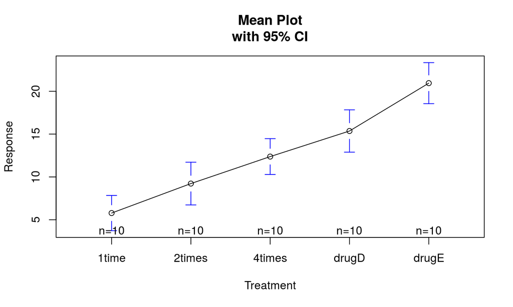

```r
library(gplots)
plotmeans(response ~ trt, xlab="Treatment", ylab="Response",
          main="Mean Plot\nwith 95% CI")
```

## *Multiple comparisons*

The ANOVA F test for treatment tells you that the five drug regimens aren’t equally effective, but it doesn’t tell you which treatments differ from one another. You can use **TukeyHSD()** function to test all pairwise differences between group means.

```r
TukeyHSD(fit)
```

```
  Tukey multiple comparisons of means
    95% family-wise confidence level

Fit: aov(formula = response ~ trt)

$trt
               diff    lwr   upr p adj
2times-1time   3.44 -0.658  7.54 0.138
4times-1time   6.59  2.492 10.69 0.000
drugD-1time    9.58  5.478 13.68 0.000
drugE-1time   15.17 11.064 19.27 0.000
4times-2times  3.15 -0.951  7.25 0.205
drugD-2times   6.14  2.035 10.24 0.001
drugE-2times  11.72  7.621 15.82 0.000
drugD-4times   2.99 -1.115  7.09 0.251
drugE-4times   8.57  4.471 12.67 0.000
drugE-drugD    5.59  1.485  9.69 0.003
```

## Assessing the normality assumption

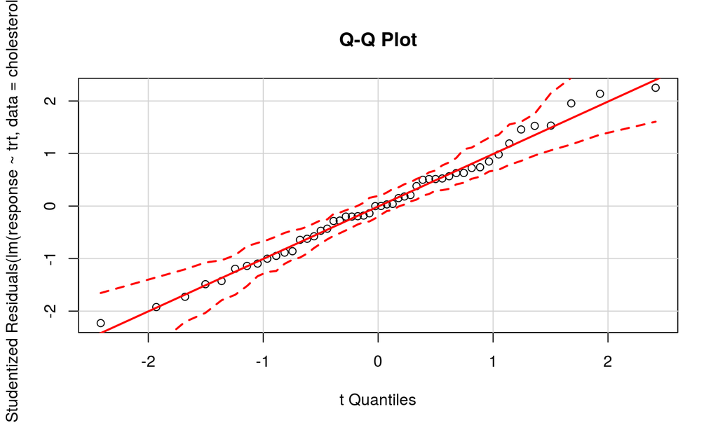

```r
library(car)
qqPlot(lm(response ~ trt, data=cholesterol), simulate=TRUE, main="Q-Q Plot", labels=FALSE)
```

## Assessing equality of variances

```r
bartlett.test(response ~ trt, data=cholesterol)
```

```
    Bartlett test of homogeneity of variances

data:  response by trt
Bartlett's K-squared = 0.6, df = 4, p-value = 1
```

Bartlett’s test indicates that the variances in the five groups don’t differ significantly.

## Test for outliers

```r
library(car)
outlierTest(fit)
```

```
No Studentized residuals with Bonferonni p < 0.05
Largest |rstudent|:
   rstudent unadjusted p-value Bonferonni p
19     2.25             0.0294           NA
```

## One-way ANCOVA

A one-way analysis of covariance (ANCOVA) extends the one-way ANOVA to include one or more quantitative covariates.

```r
data(litter, package="multcomp")
attach(litter)
table(dose)
```

```
dose
  0   5  50 500
 20  19  18  17
```

```r
head(weight)
```

```
[1] 28.1 33.3 36.4 35.5 36.8 29.6
```

```r
head(gesttime)
```

```
[1] 22.5 22.5 22.0 22.0 21.5 23.0
```

```r
aggregate(weight, by=list(dose), FUN=mean)
```

```
  Group.1    x
1       0 32.3
2       5 29.3
3      50 29.9
4     500 29.6
```

```r
aggregate(weight, by=list(dose), FUN=sd)
```

```
  Group.1    x
1       0 2.70
2       5 5.09
3      50 3.76
4     500 5.40
```

```r
fit <- aov(weight ~ gesttime + dose)
summary(fit)
```

```
            Df Sum Sq Mean Sq F value Pr(>F)
gesttime     1    134   134.3    8.05  0.006 **
dose         3    137    45.7    2.74  0.050 *
Residuals   69   1151    16.7
---
Signif. codes:  0 '***' 0.001 '**' 0.01 '*' 0.05 '.' 0.1 ' ' 1
```

- The ANCOVA F tests indicate that (a) gestation time was related to birth weight, and (b) drug dosage was related to birth weight after controlling for gestation time.
- The mean birth weight isn’t the same for each of the drug dosages, after controlling for gestation time.

Because you’re using a covariate, you may want to obtain adjusted group means — that is, the group means obtained after partialing out the effects of the covariate.

```r
library(effects)
effect("dose", fit)
```

```
 dose effect
dose
   0    5   50  500
32.4 28.9 30.6 29.3
```

- As with the one-way ANOVA example, the F test for dose indicates that the treatments don’t have the same mean birth weight, but it doesn’t tell you which means differ from one another.
- You can use the multiple comparison procedures provided by the multcomp package to compute all pairwise mean comparisons.

```r
library(multcomp)
contrast <- rbind("no drug vs. drug" = c(3, -1, -1, -1))
```

- The contrast c(3, -1, -1, -1) specifies a comparison of the first group with the average of the other three.

```r
summary(glht(fit, linfct=mcp(dose=contrast)))
```

```
     Simultaneous Tests for General Linear Hypotheses

Multiple Comparisons of Means: User-defined Contrasts


Fit: aov(formula = weight ~ gesttime + dose)

Linear Hypotheses:
                      Estimate Std. Error t value Pr(>|t|)
no drug vs. drug == 0     8.28       3.21    2.58    0.012 *
---
Signif. codes:  0 '***' 0.001 '**' 0.01 '*' 0.05 '.' 0.1 ' ' 1
(Adjusted p values reported -- single-step method)
```

## Assessing test assumptions

ANCOVA designs make the same normality and homogeneity of variance assumptions described for ANOVA designs, and you can test these assumptions using the same procedures described above.

## Two-way factorial ANOVA

In a two-way factorial ANOVA, subjects are assigned to groups that are formed from the cross-classification of two factors.

```r
attach(ToothGrowth)
head(supp)
```

```
[1] VC VC VC VC VC VC
Levels: OJ VC
```

```r
head(dose)
```

```
[1] 0.5 0.5 0.5 0.5 0.5 0.5
```

```r
table(supp, dose)
```

```
    dose
supp 0.5  1  2
  OJ  10 10 10
  VC  10 10 10
```

```r
aggregate(len, by=list(supp, dose), FUN=mean)
```

```
  Group.1 Group.2     x
1      OJ     0.5 13.23
2      VC     0.5  7.98
3      OJ     1.0 22.70
4      VC     1.0 16.77
5      OJ     2.0 26.06
6      VC     2.0 26.14
```

```r
aggregate(len, by=list(supp, dose), FUN=sd)
```

```
  Group.1 Group.2    x
1      OJ     0.5 4.46
2      VC     0.5 2.75
3      OJ     1.0 3.91
4      VC     1.0 2.52
5      OJ     2.0 2.66
6      VC     2.0 4.80
```

```r
dose <- factor(dose)
fit <- aov(len ~ supp*dose)
summary(fit)
```

```
            Df Sum Sq Mean Sq F value  Pr(>F)
supp         1    205     205   15.57 0.00023 ***
dose         2   2426    1213   92.00 < 2e-16 ***
supp:dose    2    108      54    4.11 0.02186 *
Residuals   54    712      13
---
Signif. codes:  0 '***' 0.001 '**' 0.01 '*' 0.05 '.' 0.1 ' ' 1
```

The ANOVA table indicates that both main effects (*supp* and *dose*) and the interaction between these factors are significant.

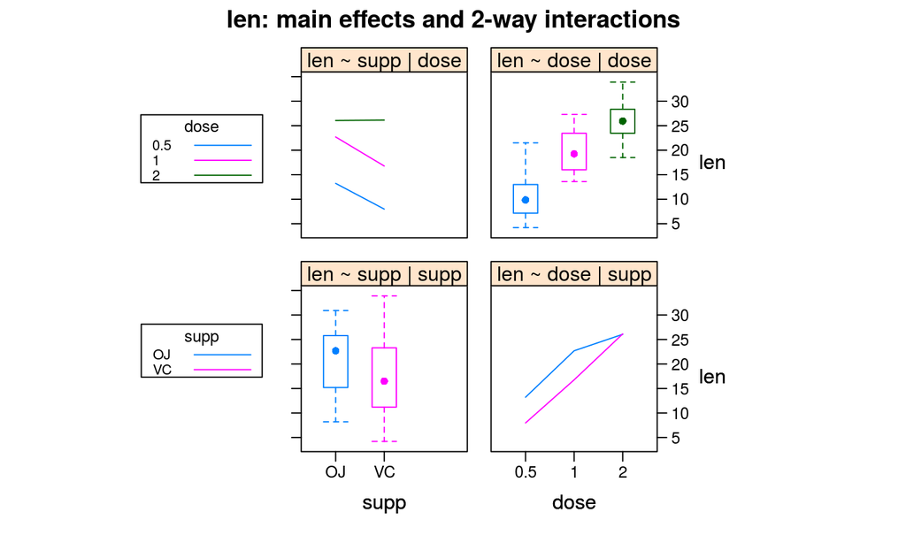

```r
library(HH)
interaction2wt(len~supp*dose)
```

## Repeated measures ANOVA

In repeated measures ANOVA, subjects are measured more than once. We focuses on a repeated measures ANOVA with one within-groups and one between-groups factor (a common design).

```r
CO2$conc <- factor(CO2$conc)
w1b1 <- subset(CO2, Treatment=='chilled')
head(w1b1)
```

```
Grouped Data: uptake ~ conc | Plant
   Plant   Type Treatment conc uptake
22   Qc1 Quebec   chilled   95   14.2
23   Qc1 Quebec   chilled  175   24.1
24   Qc1 Quebec   chilled  250   30.3
25   Qc1 Quebec   chilled  350   34.6
26   Qc1 Quebec   chilled  500   32.5
27   Qc1 Quebec   chilled  675   35.4
```

```r
fit <- aov(uptake ~ conc*Type + Error(Plant/(conc)), w1b1)
summary(fit)
```

```
Error: Plant
          Df Sum Sq Mean Sq F value Pr(>F)
Type       1   2667    2667    60.4 0.0015 **
Residuals  4    177      44
---
Signif. codes:  0 '***' 0.001 '**' 0.01 '*' 0.05 '.' 0.1 ' ' 1

Error: Plant:conc
          Df Sum Sq Mean Sq F value  Pr(>F)
conc       6   1472   245.4    52.5 1.3e-12 ***
conc:Type  6    429    71.5    15.3 3.7e-07 ***
Residuals 24    112     4.7
---
Signif. codes:  0 '***' 0.001 '**' 0.01 '*' 0.05 '.' 0.1 ' ' 1
```

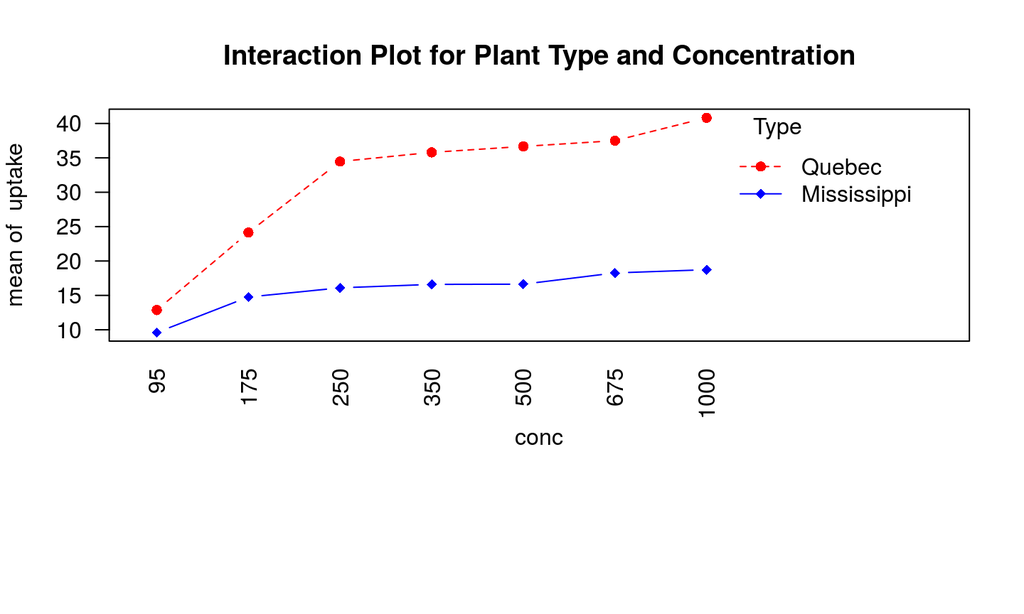

[figure not shown]

```r
par(las=2)
par(mar=c(10,4,4,2))
with(w1b1, interaction.plot(conc, Type, uptake, type="b",
                            col=c("red","blue"), pch=c(16,18),
                            main="Interaction Plot for Plant Type and Concentration"))
```